# Tarea3_Parte1

Juan Carlos Morea Guido

10 de julio de 2019

#### 1. Utilizando los paquetes devtools, usethis, packrat y el dataset Datos Churn.csv cree un proyecto de RStudio y realice los siguientes ejercicios:

#### a) Cree la estructura de carpetas para su proyecto y documente cual es el objetivo de cada una de las carpetas.

** Carpetas del proyecto:

1. data: contiene los datos tablas y modelos. Se compone a su vez por dos carpetas:

1,1. Carpeta raw: guarda la tabla leída desde la aplicación R Churn, (conjunta la tabla Datos Churn test.csv y Datos Churn train csv.

1.2. Carpeta processed: en ella se guardan la tabla ajustada para los modelos a partir de la tabla Churn. Aquí se denominó Churnproceso. Es producto del código descrito en .R/processing/Proceso.R y se utiliza en .R/modeling/ACP.R. Contiene además los dos modelos generados desde ese mismo archivo.

2. Carpeta R, que contiene los códigos de trabajo distribuidos en 3 carpetas:

2.1. preparation: Contien el archivo Churn.R y las tabla originales train y test. En el archivo .R se leen y consolidan las tablas en una sola denominada Churn.csv

2.2. processing: en ella se guarda el archivo Proceso.R que toma la tabla Churn.csv y la limpia y adecua para poder aplicarle los modelos descriptivos generando la tabla Churnproceso.csv que se guarda en data/processed

2.3. modeling: contiene el archivo ACP.R que contiene el código para el cálculo de los modelos ACP y hclust y la instrucción para guardar estos en data/processed.

3. reports: aunque se mantuvo las dos carpetas sugeridas css e imágenes, solo se utiliza la carpeta img para guardar el archivo Tarea3_parte1.rmd
4. test: se utiliza para guardar las pruebas a que se someterá la lectura inicial de la tabla de datos externa Churn.csv y asegurar que los datos no presenten problemas. Contiene los archivos test_Churn.R donde se describen los test aplicados y el archivo testthat.R que ejecuta el archivo test_Church R. Por una cuestión de sugerencia se adjunt además una copia del archivo Churn.csv dado que este no se pudo leer desde la carpeta ./data/raw.

#### b) Respetando la estructura de carpetas seleccionada realice un análisis exploratorio que cuente como mínimo con las siguientes etapas:

#### 1) Lectura de datos (csv o xlsx).

Se incluye en la carpeta ./R/preparation

#### 2) Transformación y limpieza de los datos.

Se incluye en la carpeta ./R/prosessing

#### 3) Análisis exploratorio de los datos.

la ejecución de los modelos se incluye en la carpeta ./R/modeling y la explicación abajo en este documento

#### 4) Reporte de los resultados utilizando Rmarkdown.

Este documento

#### Análisis ACP y gráficas

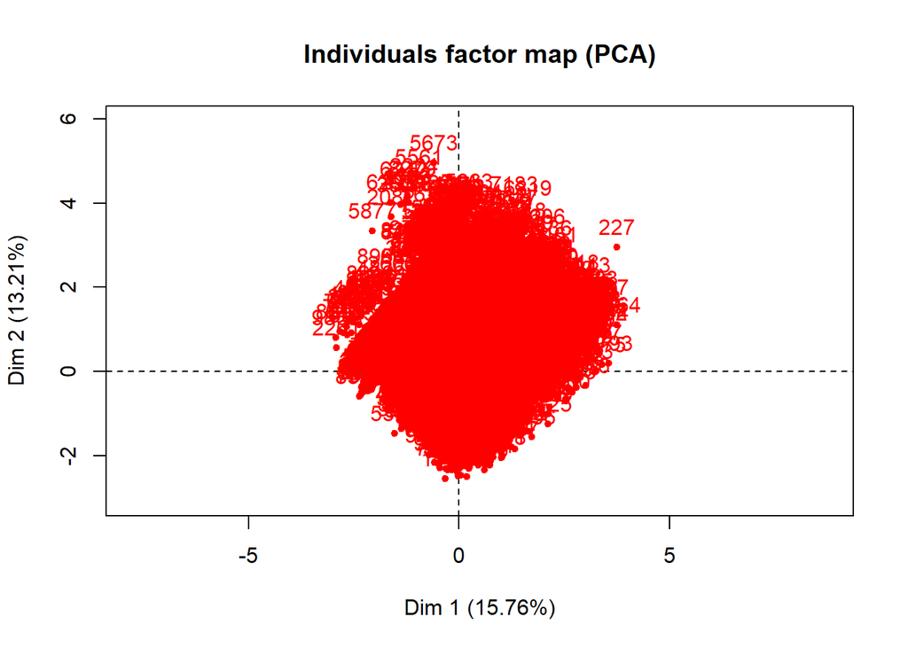

```r
res<-readRDS(file="C:/Users/Extreme PC/Documents/ProyectoTarea3/data/processed/modeloACP")

plot(res, axes=c(1, 2), choix="ind", col.ind="red",new.plot=TRUE)
```

#### Comentario

Evidente lectura poco eficiente por acúmulo de datos, sin embargo permite observar que hay individuos ubicados en todos los cuadrantes y a distintas distancias desde el centro.

Nota: La lectura desde el .rmd se debió hacer a partir del directorio raíz de la computadora lo que puede implicar problemas para lecturas posteriores por otros usuarios en otros equipos.

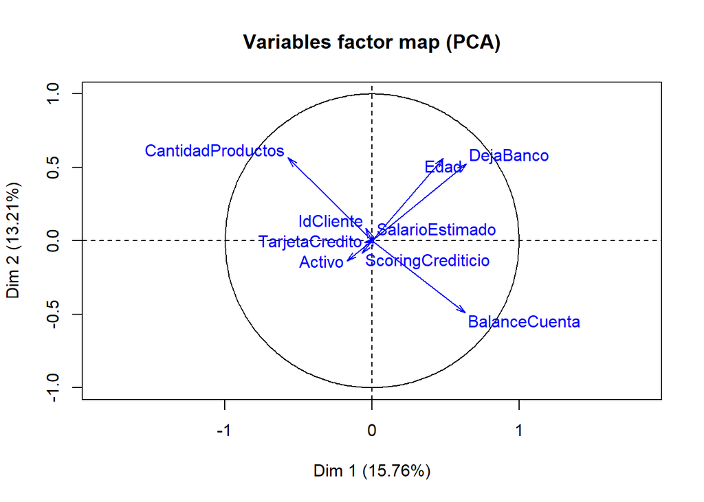

```r
plot(res, axes=c(1, 2), choix="var", col.var="blue",new.plot=TRUE)
```

#### Comentario:

Se observa una relación inversa entre el balance de cuenta y la cantidad de productos, es decir existen usuarios que guardan todo sus recursos en una sola cuenta y otros que distribuyen el capital entre varias ofertas de productos. En cualquiera de los dos casos no hay relación de estas variables con dejar el banco o con las otras variables estudiadas. La varible que sí tiene una fuerte relacion con dejar el banco es la edad, por cuanto se debe identificar las razones por las cuales hay una apetencia de las personas mayores por dejar el banco. Se debe indentificar si ello no se asocia a defunciones. El salario estimado, el scoring crediticio, la tenencia de tarjetas de crédito y la actividad son variables que impresionan tienen una mínima influencia en favor de mantenerse en el banco (oposición a variable dejabanco)

```r
cos2.ind<-(res$ind$cos2[,1]+res$ind$cos2[,2])*100
x<-cos2.ind>50

may90=cos2.ind[x]
str(may90)
```

```
##  Named num [1:1142] 51.4 72 63.6 53.1 61.8 ...
##  - attr(*, "names")= chr [1:1142] "7" "11" "34" "41" ...
```

```r
str(cos2.ind)
```

```
##  Named num [1:9837] 25.3 0.4 41.3 49.3 27.7 ...
##  - attr(*, "names")= chr [1:9837] "1" "2" "3" "4" ...
```

#### Análisis hclust y gráficas

##### Caso por grupo

```r
modelo<-readRDS(file="C:/Users/Extreme PC/Documents/ProyectoTarea3/data/processed/modelohclust")


Ngrupos <- read.table("C:/Users/Extreme PC/Documents/ProyectoTarea3/data/processed/Ngrupos.csv", header=TRUE, sep=',',dec='.',row.names=1)
head(Ngrupos)
```

```
##   IdCliente ScoringCrediticio Edad BalanceCuenta CantidadProductos
## 1  15627251               520   34     134007.90                 1
## 2  15596972               534   38          0.00                 1
## 3  15662533               598   23          0.00                 2
## 4  15670427               662   37     155187.30                 1
## 5  15682834               715   35      40169.88                 2
## 6  15728906               634   77          0.00                 2
##   TarjetaCredito Activo SalarioEstimado DejaBanco Grupo
## 1              1      1        193209.1         0     1
## 2              0      0        143938.3         0     1
## 3              1      0        153229.2         0     2
## 4              1      0         48930.8         0     3
## 5              1      1        199857.5         0     2
## 6              1      1        161579.9         0     2
```

#### Diagrama jerárquico

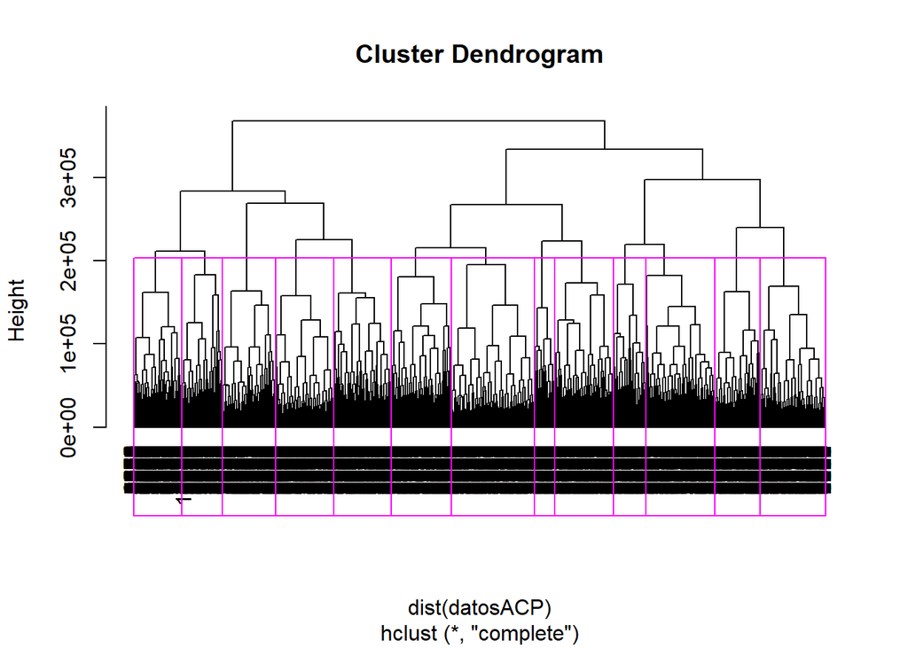

```r
plot(modelo,hang=-1)
rect.hclust(modelo, k=13, border="magenta")
```

El miismo acúmulo de datos hace difícil de identificar individuos en un clustering jerárquico.

#### Distribución de los casos por grupo

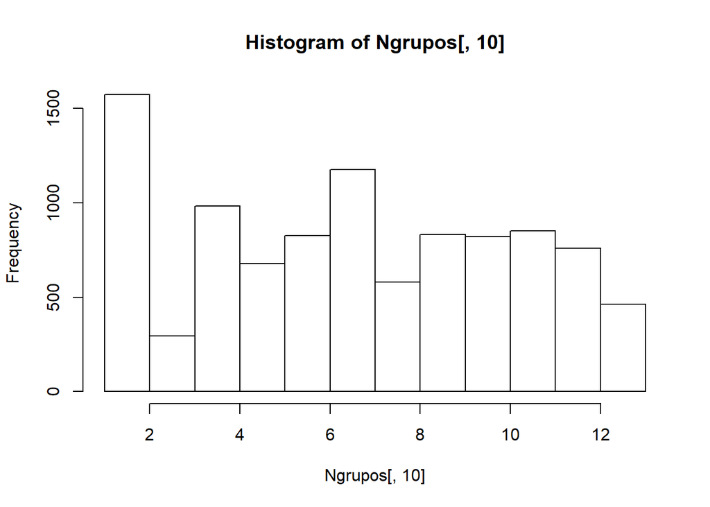

```r
hist(Ngrupos[,10])
```

Sin embargo al agrupaarlos se notan diferencias importantes entre los grupos.

```r
centros <- read.table("C:/Users/Extreme PC/Documents/ProyectoTarea3/data/processed/centros.csv", header=TRUE, sep=',',dec='.',row.names=1)
centros[,-1]
```

```
##    ScoringCrediticio     Edad BalanceCuenta CantidadProductos
## 1           651.4517 38.56854    48397.6087          1.591900
## 2           645.6466 38.27820     1717.3571          1.787325
## 3           656.2755 38.89116   150897.0248          1.370748
## 4           646.9289 38.91260   126740.7437          1.405488
## 5           651.6333 39.13255   126734.5439          1.400589
## 6           648.9322 39.14649     1874.1505          1.767554
## 7           651.1582 38.31207      104.6751          1.772109
## 8           653.2879 38.79828   139733.1406          1.360345
## 9           650.7076 39.57040   120300.8565          1.356197
## 10          650.8317 39.65854   102348.2089          1.404878
## 11          651.8558 39.06682   102552.0476          1.385698
## 12          655.4901 38.89987    52237.3572          1.579710
## 13          646.5671 39.51299   151554.5379          1.411255
##    TarjetaCredito    Activo SalarioEstimado DejaBanco
## 1       0.7102804 0.5186916       163690.95 0.2071651
## 2       0.6938776 0.5112782       142047.59 0.1342642
## 3       0.7312925 0.4591837        45627.75 0.2619048
## 4       0.7032520 0.4949187       157921.32 0.2500000
## 5       0.6936672 0.5036819       133053.91 0.2312224
## 6       0.7324455 0.5169492        62002.64 0.1392252
## 7       0.7227891 0.5255102        53123.00 0.1369048
## 8       0.7017241 0.5241379        73874.01 0.2448276
## 9       0.7328520 0.5607702        62759.81 0.2382671
## 10      0.6695122 0.5256098        45349.71 0.2414634
## 11      0.6940211 0.4923798        62734.54 0.2332943
## 12      0.6864295 0.5270092       170269.58 0.1936759
## 13      0.7121212 0.4913420       130305.31 0.2272727
```